# ANLT272~Healthcare Case Studies~Final Project: Regression

Denise Lee, Max Riching, Ali Taheri

Mar 2, 2018

# Introduction

We will use a data set that contains paid healthcare claims data for patients from a variety of commercial health care plans. We will focus on the claims recorded for patients that are using anti-diabetic drugs. The dataset features include the diagnoses, medical treatments and prescription drugs that were covered and paid for by the patients’ health care benefits plan.

There are two objectives of this analysis, the first one being to create a linear regression model to predict the total healthcare costs the patient incurs after starting use of an antidiabetic drug (post index total costs), and the second being to create a logistic regression model that can predict the patient’s daily compliance to a drug adherence of 80% or more (pdc_80_flag). These models will be trained using different features in this dataset. Among the features that are being explored are pre- and post- index claims for various comorbidity diagnoses, number of hospitalizations, number of emergency room visits and total health care expenses.

# Dataset

The claims data being used to create the models were obtained from health care providers and stored in the LifeLink Health Plan Claims Database. This database contains health care claims data from over 75 million patients enrolled in over 80 health care plans from different regions of the US [PharMetrics Legacy Health Plan Claims Data Dictionary, p. 4]. For the purposes of creating our specific models, the data was filtered to capture observations that are pertinent to patients that are using antidiabetic drugs. This involved filtering by drug class and determining the specific index date for the patient’s first use of the antidiabetic drug.

## Read and examine the data

Our first step in the process was to read in the dataset and extract the observations pertaining to the drug class of antidiabetics.

```r
d <- read.csv('DataExtract.csv', header =TRUE, stringsAsFactors = FALSE)
d <- d[d$drug_class=='*ANTIDIABETICS*',]
str(d)
```

```
## 'data.frame':    1722 obs. of  95 variables:
##  $ pdc                       : num  0.333 0.867 0.333 0.444 0.811 ...
##  $ num_ip_post               : int  0 0 0 0 0 0 0 0 0 0 ...
##  $ total_los_post            : int  0 0 0 0 0 0 0 0 0 0 ...
##  $ num_op_post               : int  4 5 0 12 4 3 0 9 2 6 ...
##  $ num_er_post               : int  0 0 0 1 0 0 0 0 0 0 ...
##  $ num_ndc_post              : int  15 16 6 15 37 5 8 40 10 18 ...
##  $ num_gpi6_post             : int  5 4 3 9 9 3 6 9 6 9 ...
##  $ adjust_total_30d_post     : num  14.47 18 5.17 14.83 37 ...
##  $ generic_rate_post         : num  0.101 0.889 1 0.528 1 ...
##  $ post_ip_flag              : int  0 0 0 0 0 0 0 0 0 0 ...
##  $ post_er_flag              : int  0 0 0 1 0 0 0 0 0 0 ...
##  $ pdc_cat                   : int  3 1 3 3 1 2 2 1 3 3 ...
##  $ post_ip_cost              : num  0 0 0 0 0 0 0 0 0 0 ...
##  $ post_er_cost              : num  0 0 0 956 0 ...
```

[output cut: 81 more lines]

After filtering by the drug class of interest, the dataset consisted of 1722 observations and 95 variables. The variables are a combination of categorical and continuous values relating to the diagnoses, medical treatments, medications, inpatient/outpatient visits and costs incurred relative to the index date for the antidiabetic drug usage. The variables of interest that we are trying to predict are post_total_cost, a continuous variable, and pdc_80_flag, a binary variable. To prepare our data for analysis, We identified categorical variables by looking at the total number of unique values for each variable. Those identified as categorical were converted to factors.

```r
#colnames(d)
```

```r
for(i in 1:ncol(d)){
  if(((length(unique(d[,i]))<=6)&(i!=2)) | (i%in%c(61,82))){
    d[,i] <- as.factor(d[,i])
  }
}
#str(d)
```

# Data Exploration

## Post Index Total Cost Distribution

Since the distribution of the post index total cost was not Guassian, we transformed the variable by taking the log of the post_total_cost value, creating a more normal distribution.

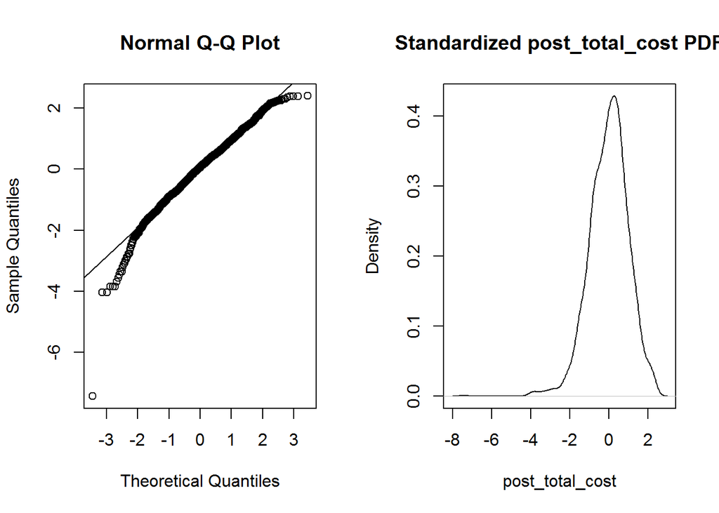

```r
#PDF of dependent variable
outcome =scale(log(d$post_total_cost))
par(mfrow=c(1,2))
qqnorm(outcome)
qqline(outcome)

plot(density(outcome) , xlab = 'post_total_cost' , main = 'Standardized post_total_cost PDF')
```

The quantiles and probability distribution of log(post_total_cost) shows an acceptably normal distribution. Additionally, We assessed the distribution of the total post-index costs in relation to the categorical predictor variables.

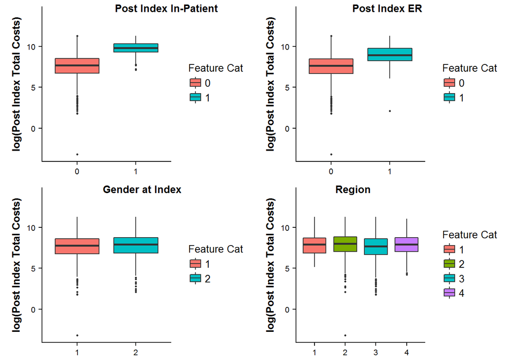

The boxplots show that there appears to be difference between patients that had more than one post hospitalization and more than one post emergency rooom visit. The gender of the patient at index did not seem make a difference, and the region did not have a significant overall impact on the distribution.

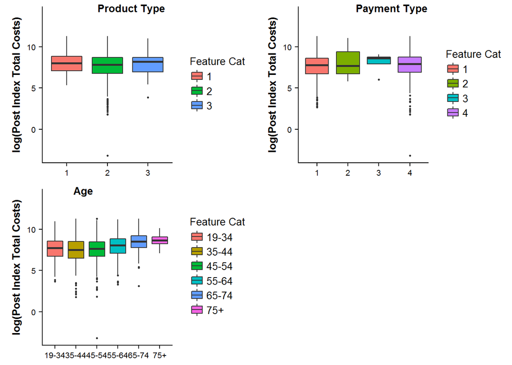

Product type and payment type appeared to have a subtle effect on the mean and distribution that was more pronounced in certain categories than others.Age group also appeared to have an effect on the distribution, with older patients having higher average costs post index. Rather than relying on a subjective visual assessment, we applied the Levene test and t-test on the categorical variables with binary factors, and used ANOVA testing for factors that had more than one level, such as the age category and region variables. To select continuous variables, we employed the built-in linear regression function in R.

We assessed the p-values at a 99% confidence level, meaning that we rejected the null hypothesis for p-values less than 0.01, implying that the population variances were significantly different enough to have predictive power on the target variable. Variables that showed multicollinearity or that were calculated from other variables were manually removed from the dataset.

```r
correlation = cor(contVar.except.outcome,d_lin$post_total_cost)
(correlation = apply(correlation, 2 , sort))
```

```
##                              [,1]
## generic_rate_post     -0.34450667
## generic_rate          -0.23623065
## log_idx_copay          0.07045790
## pre_er_cost            0.07402594
## pdc                    0.07632060
## num_er                 0.09785134
## total_los              0.13324430
## pre_ip_cost            0.13489395
## idx_copay              0.19844023
## post_er_cost           0.20254955
## numofgen               0.21410960
## pre_medical_cost       0.22879770
## generic_cost           0.23640043
## pre_op_cost            0.24933061
## total_los_post         0.29253688
## num_er_post            0.29711360
## num_op                 0.29724642
## numofgen_post          0.30460352
## pre_total_cost         0.30709791
## generic_cost_post      0.31194302
## brand_cost             0.31287697
## num_ndc                0.32117484
## pre_rx_cost            0.35190460
## adjust_total_30d       0.35199345
## num_gpi6               0.37163441
## post_ip_cost           0.38200120
## brand_cost_post        0.38503289
## numofbrand             0.38894432
## num_ip_post            0.39543936
## adjust_total_30d_post  0.45315391
## num_ndc_post           0.46125896
## numofbrand_post        0.49912957
## post_op_cost           0.52971845
## num_op_post            0.53603914
## num_gpi6_post          0.53686784
## post_medical_cost      0.59896093
```

```r
#subset selection, using all continuous variables
model = lm(d_lin$post_total_cost ~., data = d_lin)
```

We used the results from our subset selection to further filter the data for stepwise regression.

## Distribution of Patient Adherence

The second variable of interest is the patient drug adherence, which is represented by patient daily compliance of 80% captured by the variable pdc_80_flag.

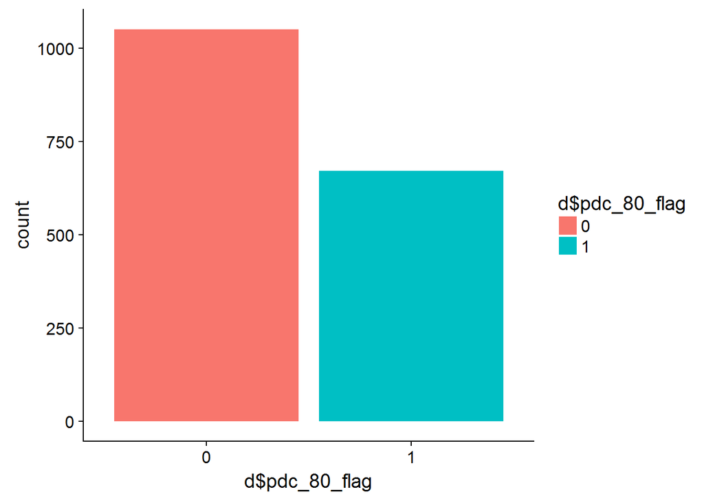

```r
ggplot(aes(d$pdc_80_flag), data = d)+geom_histogram(aes(fill=d$pdc_80_flag), stat = 'count')
```

The histogram shows that of the patients using antidiabetic drugs, less than half are adherent.

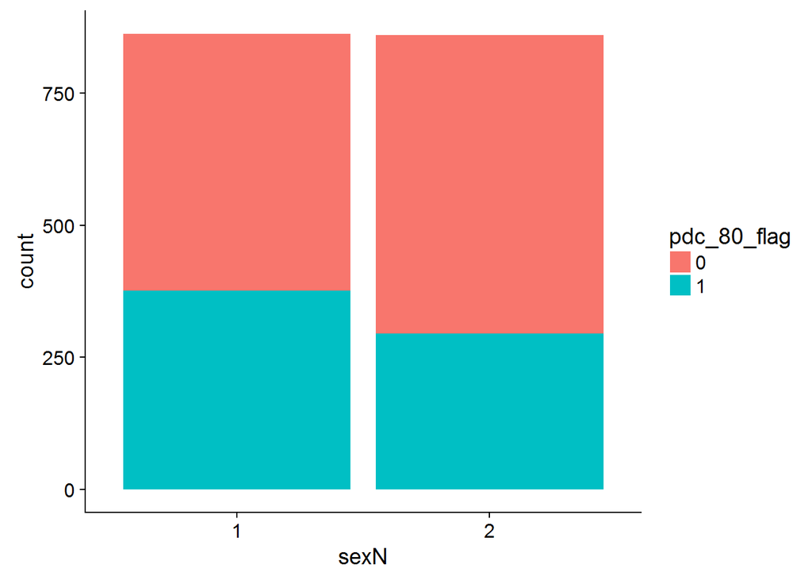

```r
ggplot(d, aes(sexN, fill=pdc_80_flag))+geom_bar()
```

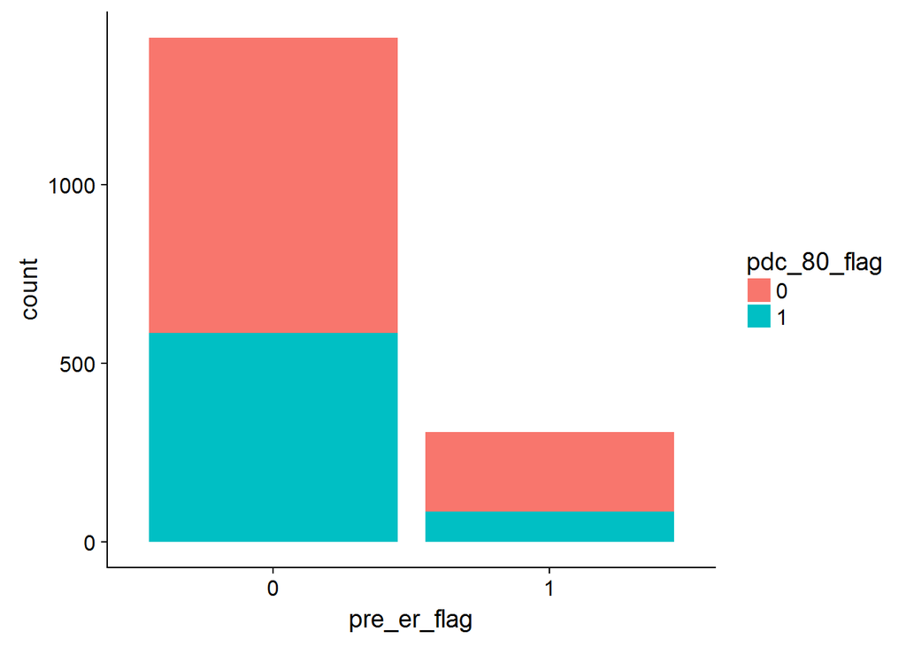

```r
ggplot(d, aes(pre_er_flag, fill=pdc_80_flag))+geom_bar()
```

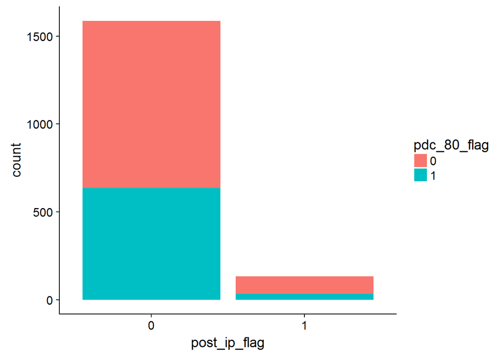

```r
ggplot(d, aes(post_ip_flag, fill=pdc_80_flag))+geom_bar()
```

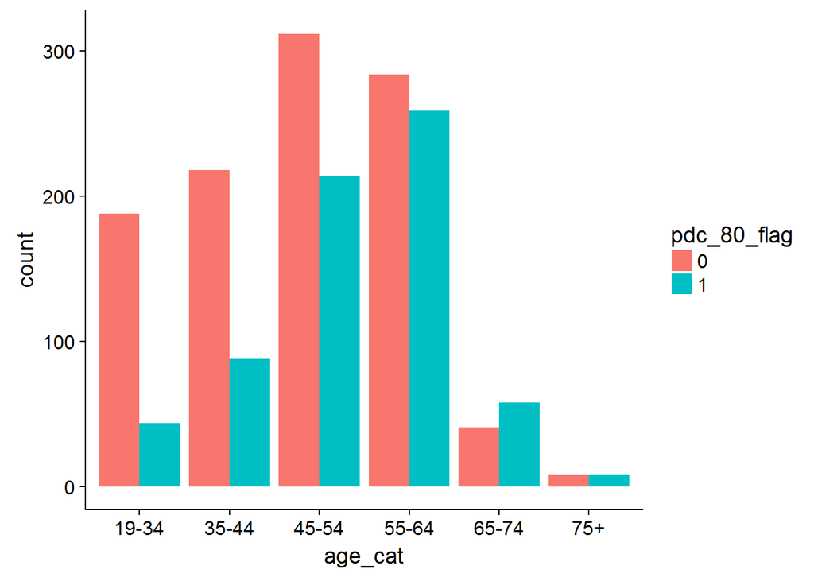

```r
ggplot(d, aes(age_cat, fill=pdc_80_flag))+geom_bar(position = 'dodge')
```

The boxplots show that drug adherence is slightly less among female patients and appears significantly less in patients that have more than one pre-index emergency room visit. Among the age categories, adherence improves as that age of the patients increase.

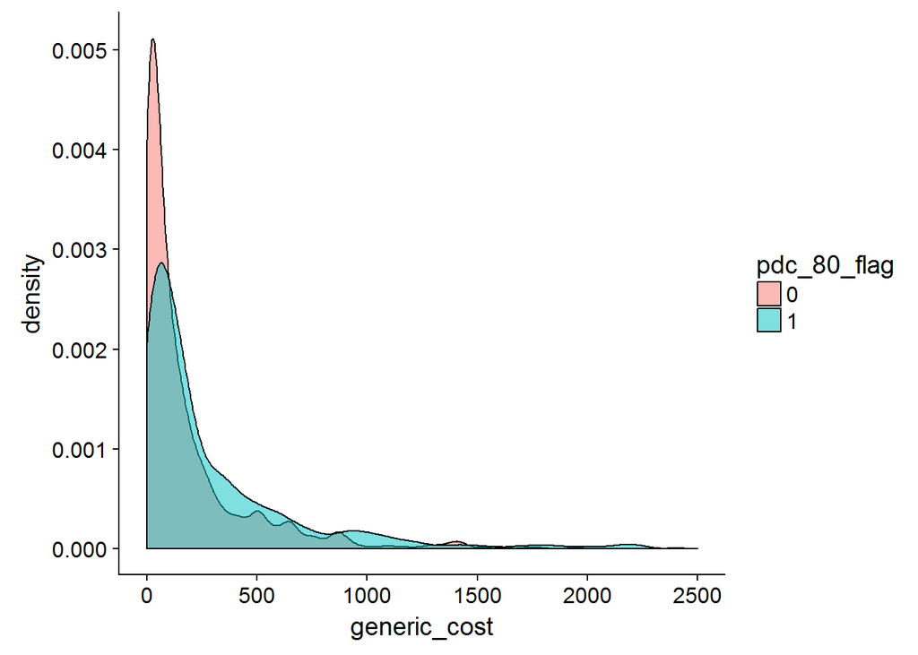

```r
ggplot(d, aes(generic_cost,fill=pdc_80_flag))+geom_density(alpha=0.5)+xlim(0,2500)
```

The distribution did not show much separation due to the cost among generic drugs.

```r
#Select variables for logistic model
d_log <- d[,-c(1,12,50,92,94,95)] # don't need pdc, know drug class since we filtered on it
```

# Train, Test and Validation Sets

To create our training and validation sets, we followed a general rule of thumb to set aside twenty percent of our data for validation testing. The hold-out set was randomly selected by row index. Since the logistic regression model required the removal of values that were “N/A”, the hold-out sets were selected indvidually for each model.

```r
#Separating train and test data
set.seed(2018)

#Sample Indexes for linear model Cross-Validation
indices = sample(1:nrow(d), size=0.2*nrow(d_lin))

testD_lin = d_lin[indices,]
trainD_lin = d_lin[-indices,]

#Remove na values and sample for logistic model cross-validation
d_log <- na.omit(d_log)
sample <- sample.int(n = nrow(d_log), size = floor(0.8*nrow(d_log)), replace=F)
train <- d_log[sample,]
test <- d_log[-sample,]
```

# Linear Regression Model

## Stepwise Regression

Stepwise linear regression was performed on 18 continuous features selected by p-values determined from using the built-in R function for linear regression.

### Model Assumptions

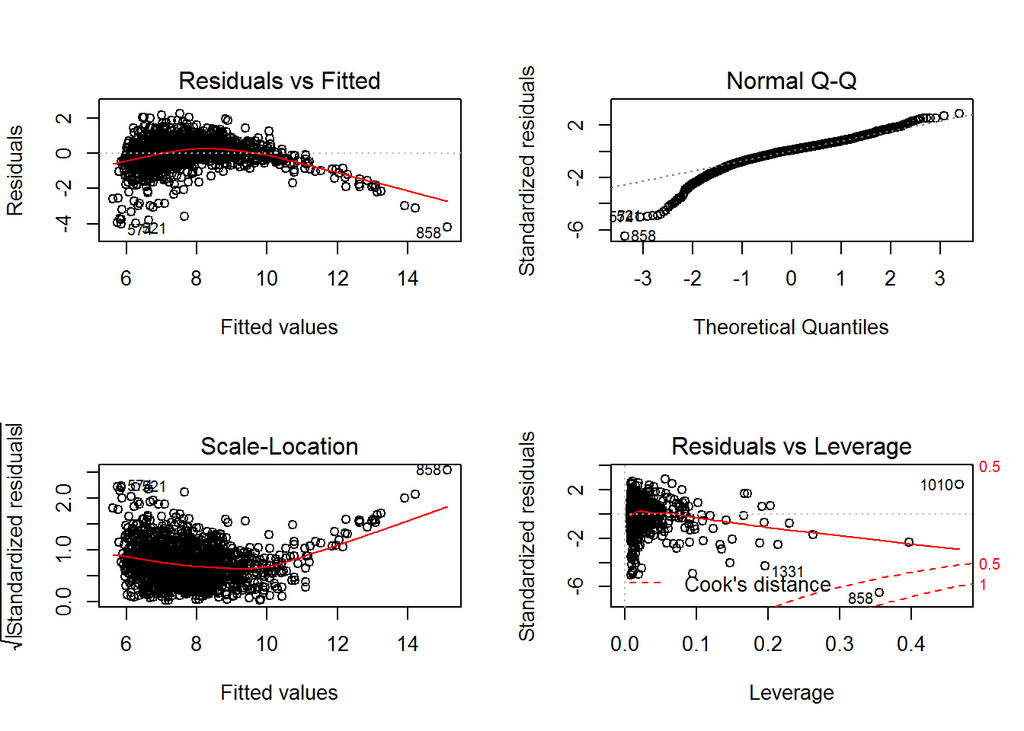

```r
#Residual Analysis
par(mfrow=c(2,2))
plot(m19)
```

The residual analysis showed a slight deterministic pattern. More analysis into the data would be required to improve the residual distribution. Overall, the model assumptions for linearity were acceptable.

### Cross-Validation for Stepwise Linear Model

```r
#Cross Validation
xTest = model.matrix(post_total_cost ~ ., data = testD_lin)[,-1]
prediction= predict(m19, newx = xTest)

Eout= mean((testD_lin$post_total_cost - prediction)^2)
```

Testing our model with the hold-out set returned an MSE of 3.62.

## Backward and Forward Linear Regression

To improve on our error rate determined from the validation set, backward and forward stepwise regression were implemented using the built-in function regsubsets() function in R.

```r
#Forward solution
subsetMod= regsubsets(post_total_cost ~ . , data = trainD_lin, method ="forward" , nvmax=20)
```

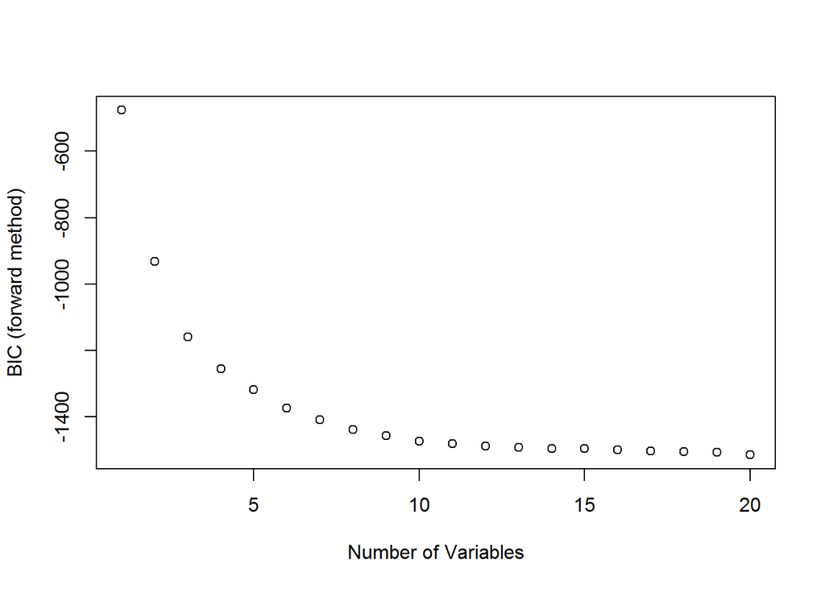

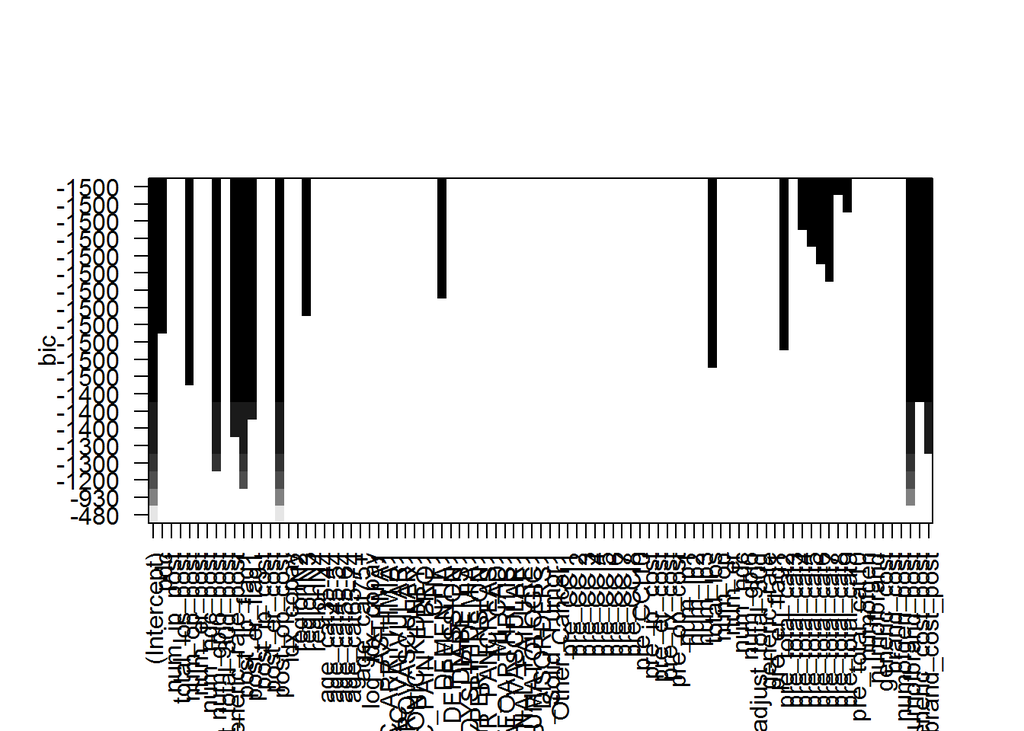

```r
xTest = model.matrix(post_total_cost ~ ., data = testD_lin)

#Calculate MSE
Eout= mean((sapply(1:nrow(testD_lin),
                   function(k) xTest[k,names(coefficients)] %*% coefficients
                   ) - testD_lin$post_total_cost)^2)

adjr <- (subsetModSum$adjr2)
#number of variables with highest adjusted r^2
var<- which.max(subsetModSum$adjr2)
```

```r
coef(subsetMod, which.max(subsetModSum$adjr2))
```

```
##       (Intercept)               pdc       num_op_post     num_gpi6_post
##      6.997264e+00      2.659879e-01      1.874408e-02      5.951088e-02
## generic_rate_post     post_ip_flag1     post_er_flag1      post_op_cost
##     -1.052476e+00      1.335755e+00      5.324067e-01      8.518855e-05
##          regionN3         DEMENTIA1         total_los    pre_total_cat2
##     -1.398739e-01     -1.150665e+00     -3.320498e-02     -2.591776e-02
##    pre_total_cat4    pre_total_cat5    pre_total_cat6    pre_total_cat7
##      3.352342e-01      4.235615e-01      4.421049e-01      4.749791e-01
##    pre_total_cat8    pre_total_cat9   numofbrand_post generic_cost_post
##      3.442570e-01      3.703543e-01      1.418166e-02      3.249309e-04
##   brand_cost_post
##      7.589264e-05
```

```r
#Backward solution
subsetMod= regsubsets(post_total_cost ~ . , data = trainD_lin, method ="backward" , nvmax=20)
```

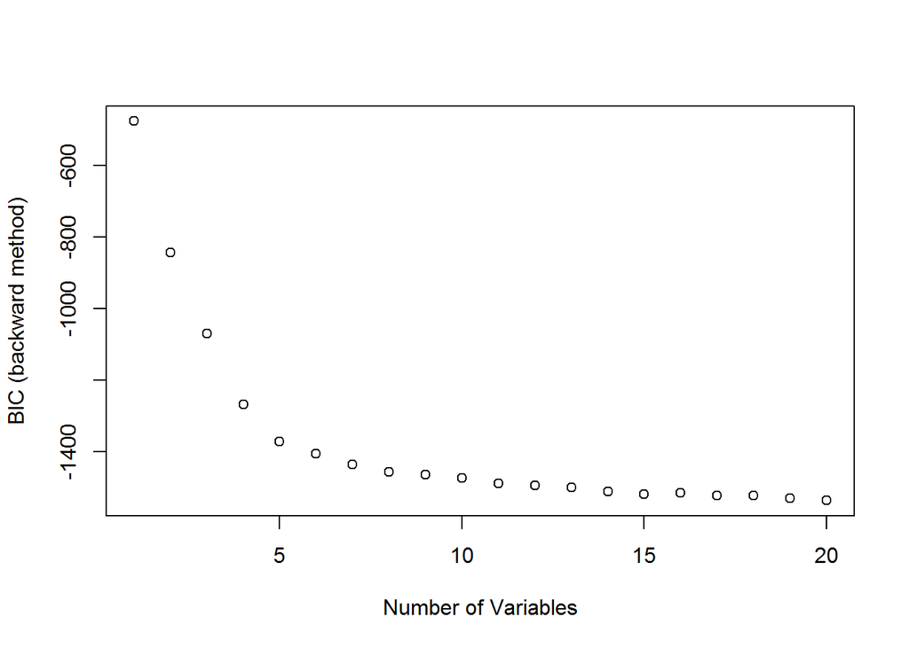

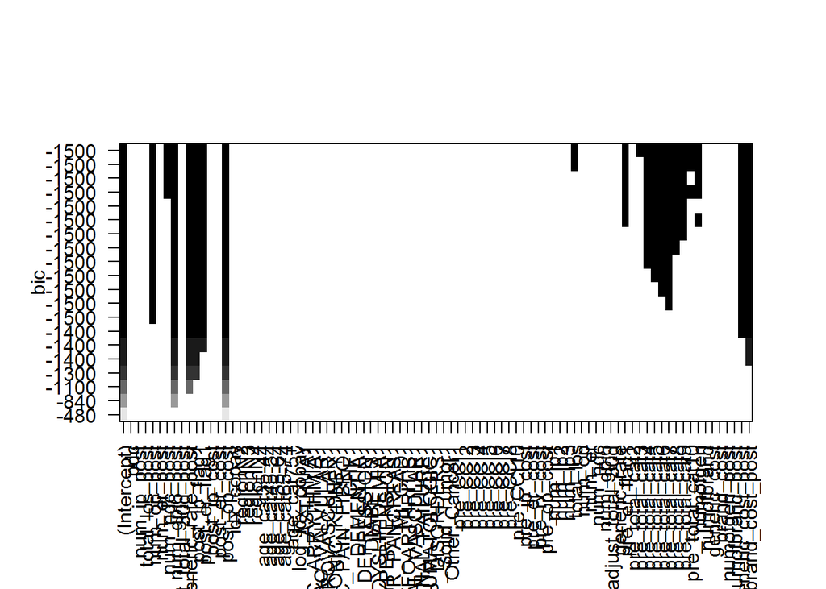

```
##       (Intercept)       num_op_post      num_ndc_post     num_gpi6_post
##      6.946192e+00      1.720314e-02      1.554512e-02      4.863866e-02
## generic_rate_post     post_ip_flag1     post_er_flag1      post_op_cost
##     -1.023552e+00      1.247353e+00      5.562170e-01      8.327462e-05
##         total_los      pre_er_flag1    pre_total_cat3    pre_total_cat4
##     -4.775222e-02     -2.721162e-01      2.840153e-01      5.318473e-01
##    pre_total_cat5    pre_total_cat6    pre_total_cat7    pre_total_cat8
##      6.653336e-01      7.170427e-01      7.599167e-01      6.726430e-01
##    pre_total_cat9   pre_total_cat10          numofgen generic_cost_post
##      7.777822e-01      6.515825e-01     -1.708226e-02      2.897439e-04
##   brand_cost_post
##      6.913786e-05
```

### Ridge Regression using glmnet library

```r
#Set alpha to zero for Ridge
ridMod = glmnet(x,trainD_lin$post_total_cost, alpha = 0, lambda = lambdaRange)
```

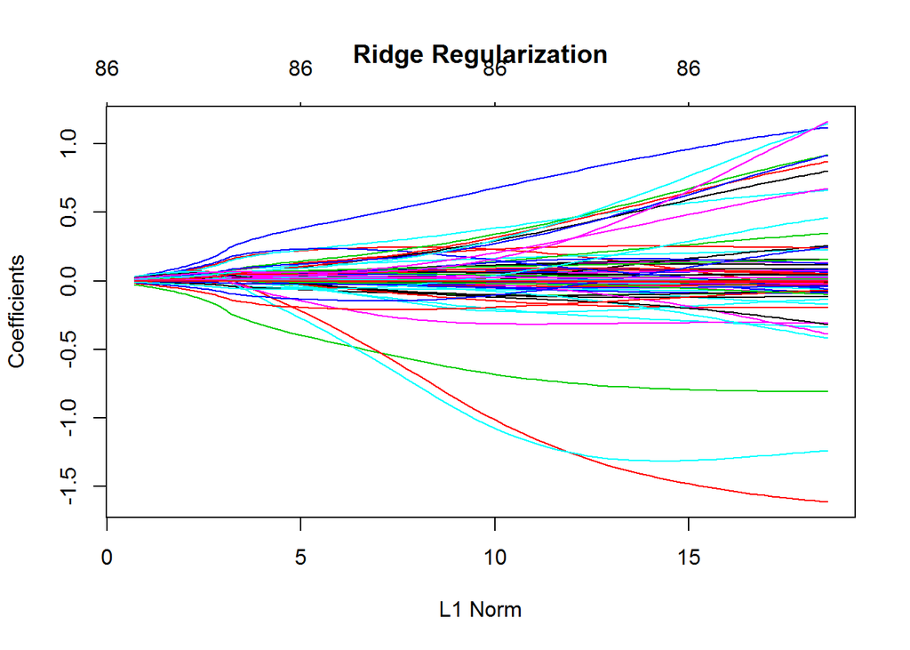

## Cross-Validation for Ridge

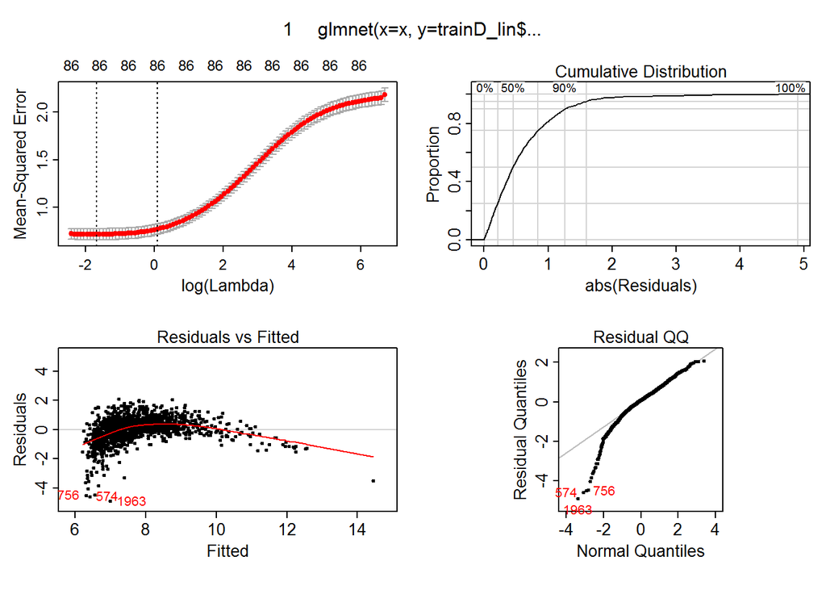

```r
cv.out = cv.glmnet(x, trainD_lin$post_total_cost, alpha = 0)
plotres(cv.out)
```

```r
bestLambda = cv.out$lambda.min

coef(cv.out, s = bestLambda)
```

```
## 87 x 1 sparse Matrix of class "dgCMatrix"
##                                         1
## (Intercept)                  6.991697e+00
## pdc                          7.648787e-02
## num_ip_post                  1.850418e-01
## total_los_post              -2.115572e-02
## num_op_post                  2.339866e-02
## num_er_post                 -4.445602e-02
## num_ndc_post                 6.454031e-03
## num_gpi6_post                4.135476e-02
## adjust_total_30d_post        3.992944e-03
## generic_rate_post           -7.458064e-01
## post_ip_flag1                7.980860e-01
## post_er_flag1                4.625239e-01
## post_ip_cost                 2.141430e-05
## post_er_cost                 1.204037e-04
## post_op_cost                 7.171545e-05
## idx_copay                    4.976599e-03
## regionN2                     8.301888e-02
## regionN3                    -6.587528e-02
## regionN4                     1.300085e-01
## age_cat35-44                -1.169992e-01
## age_cat45-54                -4.023184e-02
## age_cat55-64                 2.752789e-03
## age_cat65-74                 6.053646e-02
## age_cat75+                   1.816257e-01
## log_idx_copay               -1.467886e-02
## ASTHMA1                      1.337934e-01
## CARDIAC_ARRYTHMIA1           7.656016e-02
## CARDIAC_VALVULAR1            1.918297e-01
## CEREBROVASCULAR1             1.858680e-02
## CHRONIC_KIDNEY1             -2.453336e-01
## CHRONIC_PAIN_FIBRO1         -2.656816e-03
## CHF1                         6.919817e-02
## DEMENTIA1                   -1.259693e+00
## DEPRESSION1                 -1.034642e-01
## DIABETES1                   -7.004882e-02
## DYSLIPIDEMIA1               -7.997038e-03
## HYPERTENSION1                5.759835e-02
## LIVER_GALLBLADDER_PANCREAS1  4.982033e-02
```

[output cut: 34 more lines]

```
## pre_total_cat4               3.104064e-01
## pre_total_cat5               4.061760e-01
## pre_total_cat6               4.426421e-01
## pre_total_cat7               4.628752e-01
## pre_total_cat8               3.967643e-01
## pre_total_cat9               4.601608e-01
## pre_total_cat10              3.120576e-01
## numofgen                    -5.293740e-03
## numofbrand                  -5.640890e-03
## generic_cost                -6.052958e-06
## brand_cost                   1.080219e-05
## numofgen_post                2.125583e-03
## numofbrand_post              2.239544e-02
## generic_cost_post            2.498543e-04
## brand_cost_post              4.586675e-05
```

```r
xTest = model.matrix(post_total_cost ~ ., data = testD_lin)[,-1]
prediction= predict(ridMod, newx = xTest, s = bestLambda)
Eout= mean((testD_lin$post_total_cost - prediction)^2)
```

Using ridge regression, the best $\lambda$ occured at 86 coefficients that included all features. The MSE was 0.82 and the lambda value was 0.1867.

## Lasso Regression using glmnet library

```r
#Set alpha to one for lasso
lassoMod = glmnet(x,trainD_lin$post_total_cost, alpha = 1 , lambda = lambdaRange)
```

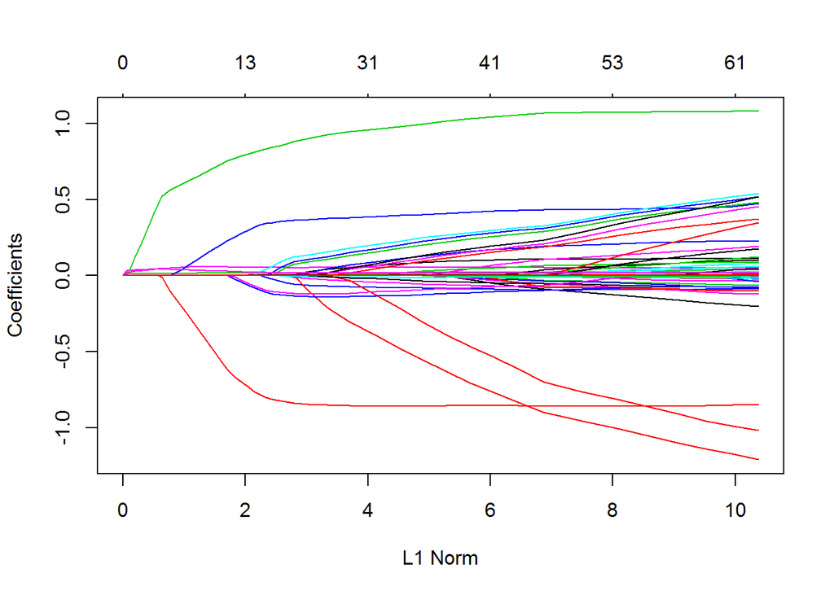

## Cross-Validation for Lasso

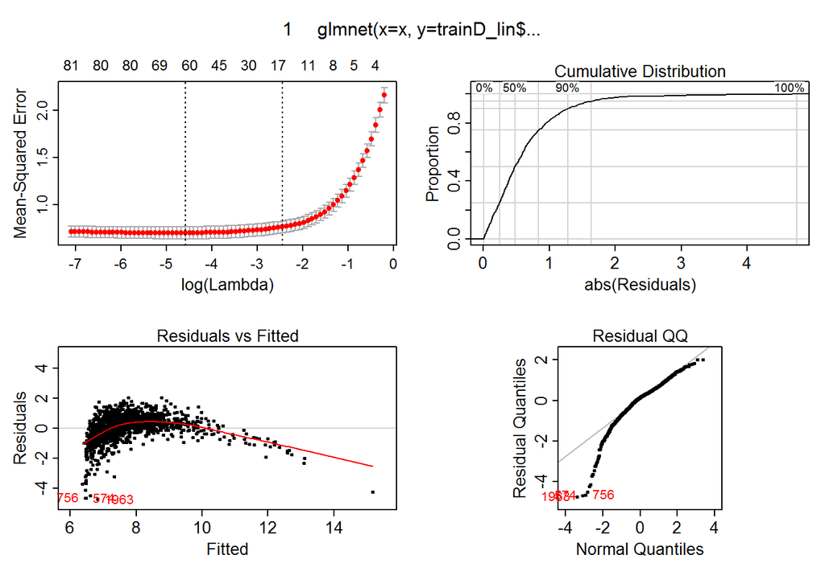

```r
cv.out = cv.glmnet(x, trainD_lin$post_total_cost, alpha = 1)
plotres(cv.out)
```

```r
bestLambda = cv.out$lambda.min

coef(cv.out, s = bestLambda)
```

```
## 87 x 1 sparse Matrix of class "dgCMatrix"
##                                         1
## (Intercept)                  6.948968e+00
## pdc                          1.103582e-01
## num_ip_post                  .
## total_los_post              -1.987289e-02
## num_op_post                  2.149693e-02
## num_er_post                 -2.057771e-02
## num_ndc_post                 4.742269e-03
## num_gpi6_post                4.957317e-02
## adjust_total_30d_post        3.380630e-03
## generic_rate_post           -8.497133e-01
## post_ip_flag1                1.079403e+00
## post_er_flag1                4.698529e-01
## post_ip_cost                 1.991281e-05
## post_er_cost                 9.046137e-05
## post_op_cost                 8.126400e-05
## idx_copay                    4.366487e-03
## regionN2                     3.935228e-02
## regionN3                    -8.915233e-02
## regionN4                     5.980196e-02
## age_cat35-44                -9.991889e-02
## age_cat45-54                -1.657565e-02
## age_cat55-64                 .
## age_cat65-74                 1.549812e-02
## age_cat75+                   1.214992e-01
## log_idx_copay               -1.303694e-02
## ASTHMA1                      8.042587e-02
## CARDIAC_ARRYTHMIA1           .
## CARDIAC_VALVULAR1            1.904033e-01
## CEREBROVASCULAR1             .
## CHRONIC_KIDNEY1             -2.009477e-01
## CHRONIC_PAIN_FIBRO1          .
## CHF1                         .
## DEMENTIA1                   -1.203161e+00
## DEPRESSION1                 -6.376160e-02
## DIABETES1                   -8.113296e-02
## DYSLIPIDEMIA1                .
## HYPERTENSION1                2.857335e-02
## LIVER_GALLBLADDER_PANCREAS1  .
```

[output cut: 34 more lines]

```
## pre_total_cat4               3.689949e-01
## pre_total_cat5               4.780734e-01
## pre_total_cat6               5.132391e-01
## pre_total_cat7               5.345300e-01
## pre_total_cat8               4.498754e-01
## pre_total_cat9               5.125614e-01
## pre_total_cat10              3.404682e-01
## numofgen                    -3.933320e-03
## numofbrand                   .
## generic_cost                 .
## brand_cost                   4.382749e-06
## numofgen_post                .
## numofbrand_post              1.673829e-02
## generic_cost_post            2.662580e-04
## brand_cost_post              6.136192e-05
```

```r
xTest = model.matrix(post_total_cost ~ ., data = testD_lin)[,-1]
prediction= predict(ridMod, newx = xTest, s = bestLambda)
Eout=mean((testD_lin$post_total_cost - prediction)^2)
```

Using lasso regression, the best $\lambda$ occured at approximately 60 coefficients that included 45 features. The MSE was 0.821 and the lambda value was 0.0102.

# Logistic Regression Model

To build a logistic regression model for predicting patient adherence, ridge and lasso regression was applied, followed by cross-validation to find the optimal $\lambda$ value and preferred number of features and coefficients.

```r
#Expected Outputs
ytrain <- train$pdc_80_flag
ytest <- test$pdc_80_flag
```

## Ridge Regression in glmnet

```r
x <- model.matrix(pdc_80_flag~.,data=train)[,-1]
x.test <- model.matrix(pdc_80_flag~.,data=test)[,-1]

ridMod <- glmnet(x,ytrain,alpha =0, family="binomial")
```

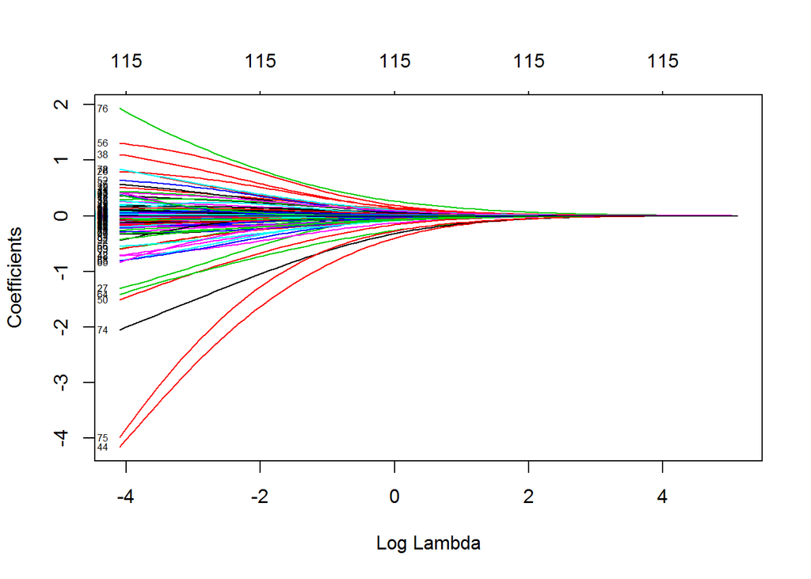

## Cross-Validation for Ridge

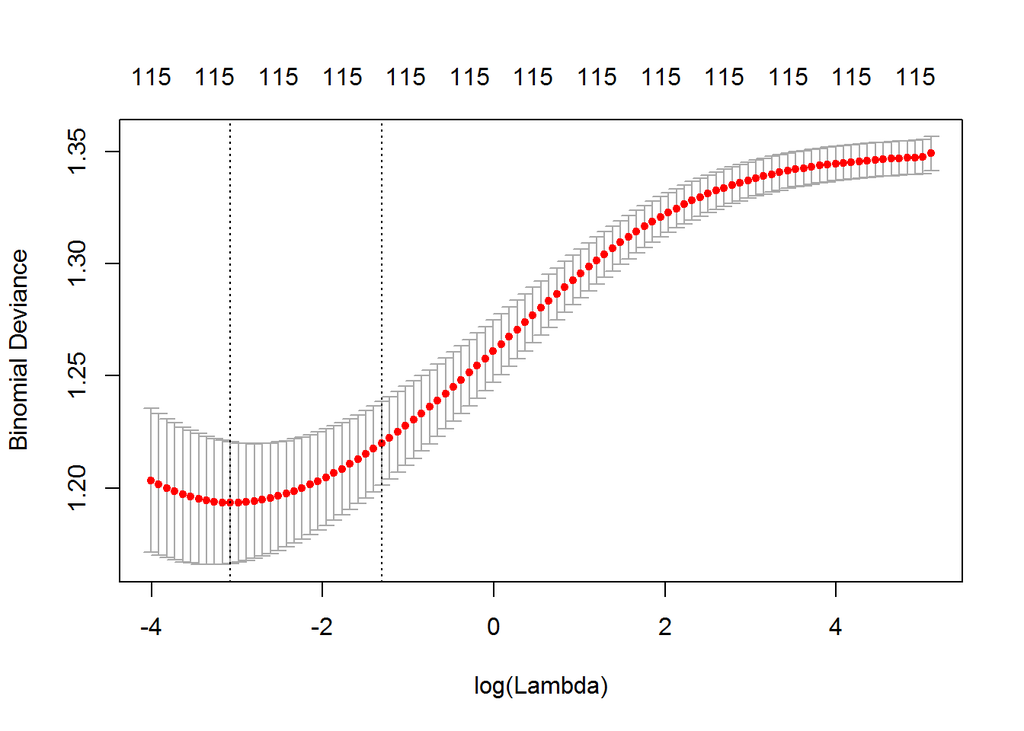

```r
cv.ridge <- cv.glmnet(x, y=ytrain, alpha=0,family="binomial")
plot(cv.ridge)
```

```r
best.lambda.ridge <- cv.ridge$lambda.min
```

As expected for ridge regression, every variable in the model has a non-zero coefficient. By cross-validation, the best value for lambda is about 0.0461 for 115 coefficients.

The coefficients associated with the ridge regression model are as follows:

```r
coef(ridMod, s=best.lambda.ridge)
```

```
## 117 x 1 sparse Matrix of class "dgCMatrix"
##                                         1
## (Intercept)                 -1.852758e+00
## num_ip_post                 -1.241618e-01
## total_los_post              -1.760570e-02
## num_op_post                  8.496356e-03
## num_er_post                 -1.679147e-01
## num_ndc_post                 1.451621e-02
## num_gpi6_post               -8.373375e-02
## adjust_total_30d_post        4.173385e-02
## generic_rate_post            6.066702e-01
## post_ip_flag1               -2.030642e-01
## post_er_flag1               -1.573822e-01
## post_ip_cost                 3.534537e-06
## post_er_cost                -1.060446e-05
## post_rx_cost                -1.274329e-05
## post_op_cost                -6.243641e-06
## post_total_cost             -2.667438e-06
## post_medical_cost           -1.192222e-06
## idx_copay                    3.685138e-04
## age_grpN3                    2.159713e-01
## age_grpN4                    4.254084e-01
## sexN2                       -1.784084e-01
## regionN2                     4.673720e-02
## regionN3                    -1.914689e-01
## regionN4                     6.001247e-02
## idx_prodtypeN2              -2.197615e-02
## idx_prodtypeN3               8.759737e-02
## idx_paytypN2                 7.030406e-01
## idx_paytypN3                -9.453152e-01
## idx_paytypN4                 4.582215e-02
## age_cat35-44                 1.309995e-01
## age_cat45-54                 6.925106e-02
## age_cat55-64                 1.676485e-01
## age_cat65-74                 4.238212e-01
## age_cat75+                   3.790918e-01
## log_idx_copay               -5.001818e-02
## ALCOHOL_DRUG1                1.739713e-01
## ASTHMA1                     -6.391892e-02
## CARDIAC_ARRYTHMIA1           4.446022e-01
```

[output cut: 64 more lines]

```
## pre_total_cat5              -1.241677e-01
## pre_total_cat6               3.629199e-01
## pre_total_cat7              -1.100251e-01
## pre_total_cat8              -1.250295e-01
## pre_total_cat9              -7.069452e-02
## pre_total_cat10              1.628773e-01
## numofgen                    -1.463973e-02
## numofbrand                  -1.551189e-02
## generic_cost                -2.875217e-05
## brand_cost                   6.127147e-06
## ratio_G_total_cost           1.720088e-01
## numofgen_post                1.754573e-02
## numofbrand_post              1.761883e-02
## generic_cost_post            1.118949e-05
## brand_cost_post              2.568432e-06
```

## Lasso Regression

```r
lassMod <- glmnet(x,ytrain,alpha =1, family="binomial")
```

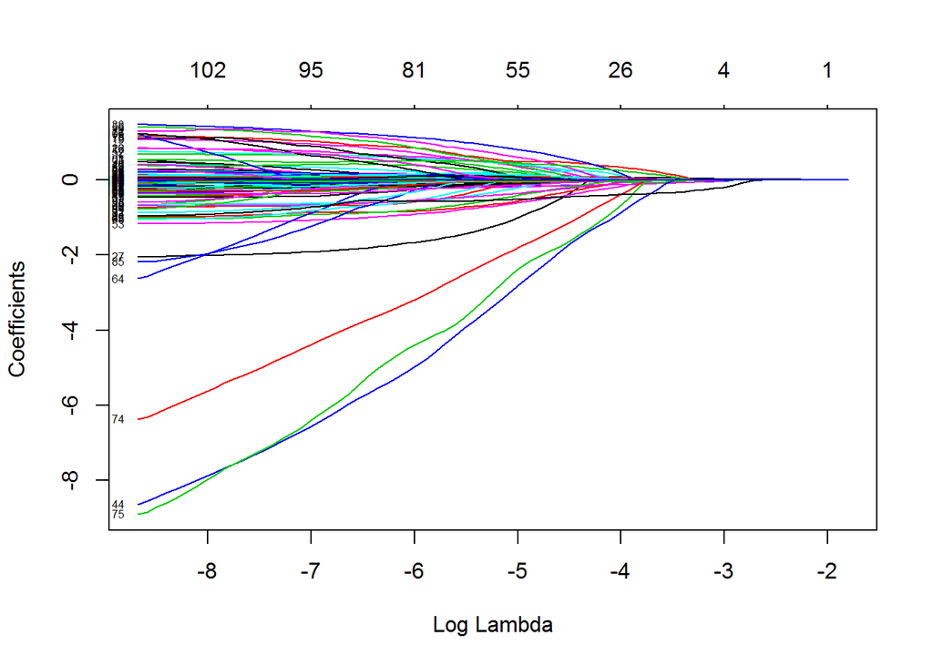

```r
plot(lassMod,xvar="lambda", label=TRUE)
```

## Cross-Validation for Lasso

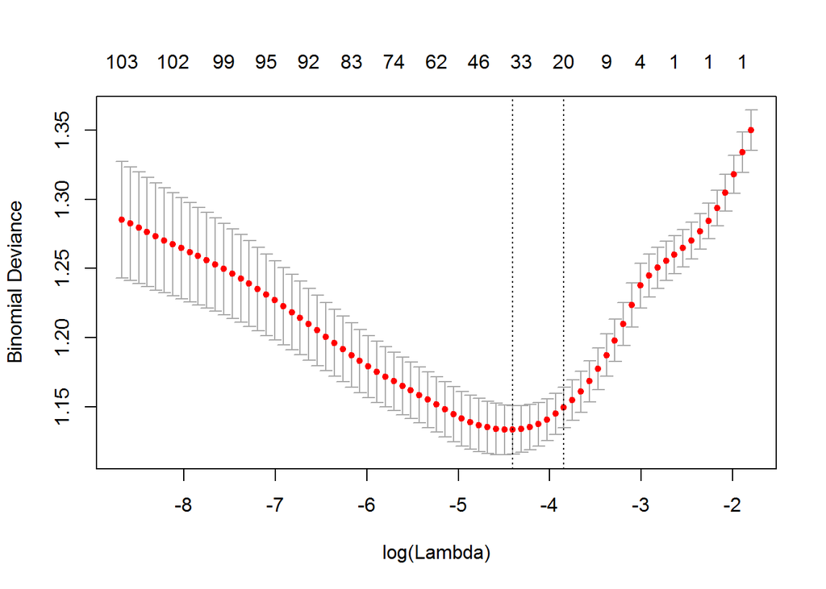

```r
cv.lasso <- cv.glmnet(x, y=ytrain, alpha=1,family="binomial")
plot(cv.lasso)
```

```r
best.lambda.lasso <- cv.lasso$lambda.min
```

By cross-validation, the best value for lambda is about 0.0122 at approximantely 30-40 coefficients that included 27 features.

The coefficients associated with the lasso regression model are as follows:

```r
coef(lassMod, s=best.lambda.lasso)
```

```
## 117 x 1 sparse Matrix of class "dgCMatrix"
##                                         1
## (Intercept)                 -1.155553e+00
## num_ip_post                  .
## total_los_post              -6.204151e-03
## num_op_post                  .
## num_er_post                 -1.425273e-01
## num_ndc_post                 .
## num_gpi6_post               -1.470926e-01
## adjust_total_30d_post        8.187164e-02
## generic_rate_post            4.452293e-01
## post_ip_flag1               -3.746382e-02
## post_er_flag1                .
## post_ip_cost                 .
## post_er_cost                 .
## post_rx_cost                 .
## post_op_cost                 .
## post_total_cost             -8.060379e-07
## post_medical_cost            .
## idx_copay                    .
## age_grpN3                    6.332386e-02
## age_grpN4                    5.411532e-02
## sexN2                       -3.984993e-02
## regionN2                     .
## regionN3                    -4.843135e-02
## regionN4                     .
## idx_prodtypeN2               .
## idx_prodtypeN3               .
## idx_paytypN2                 1.062465e-01
## idx_paytypN3                -1.778181e-01
## idx_paytypN4                 .
## age_cat35-44                 .
## age_cat45-54                 .
## age_cat55-64                 .
## age_cat65-74                 2.524529e-01
## age_cat75+                   .
## log_idx_copay               -2.917230e-02
## ALCOHOL_DRUG1                .
## ASTHMA1                      .
## CARDIAC_ARRYTHMIA1           .
```

[output cut: 64 more lines]

```
## pre_total_cat5               .
## pre_total_cat6               3.455276e-01
## pre_total_cat7               .
## pre_total_cat8               .
## pre_total_cat9               .
## pre_total_cat10              .
## numofgen                     .
## numofbrand                   .
## generic_cost                 .
## brand_cost                   .
## ratio_G_total_cost           .
## numofgen_post                .
## numofbrand_post              .
## generic_cost_post            .
## brand_cost_post              .
```

## Prediction with Ridge and Lasso

```
##
## Call:
## roc.formula(formula = preds[, 3] ~ preds[, 1])
##
## Data: preds[, 1] in 208 controls (preds[, 3] 1) < 122 cases (preds[, 3] 2).
## Area under the curve: 0.7519
```

```
##
## Call:
## roc.formula(formula = preds[, 3] ~ preds[, 2])
##
## Data: preds[, 2] in 208 controls (preds[, 3] 1) < 122 cases (preds[, 3] 2).
## Area under the curve: 0.7751
```

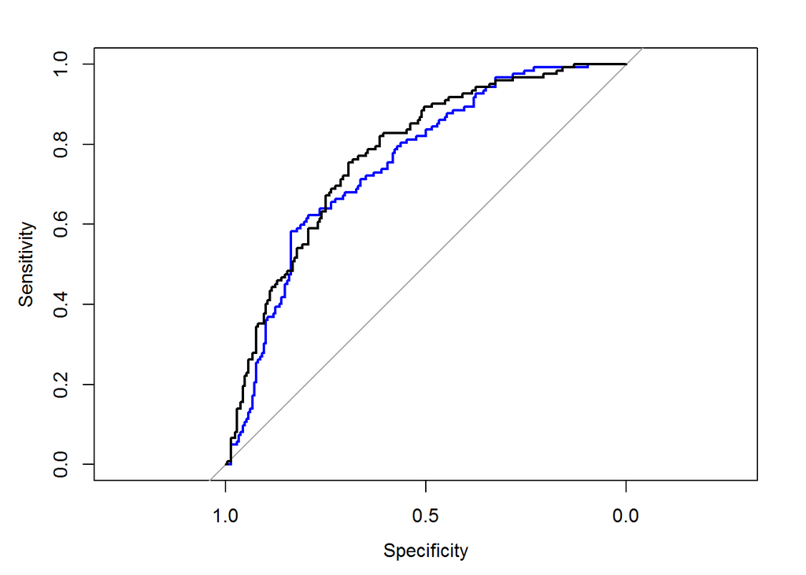

In the plot above, the ridge model is shown in blue and the lasso in black. The lasso model showed a slightly higher ROC AUC score of 0.78 in comparison to the ridge model at 0.75. Visually, the shape of the two curves do not different significantly.

```
## Ridge Classification Rate: 0.73
```

```
## Lasso Classification Rate: 0.72
```

Patient adherence of 1 was assigned to outputs greater than 0.5. These patients would be classified as at least 80% compliant with drug adherence. Although the classification rate is slightly lower, we favor the lasso regression which is more sparse at approximately 30 to 40 coefficients compared to 115 in the ridge. The lasso regression model was further evaluated at different values for lambda.

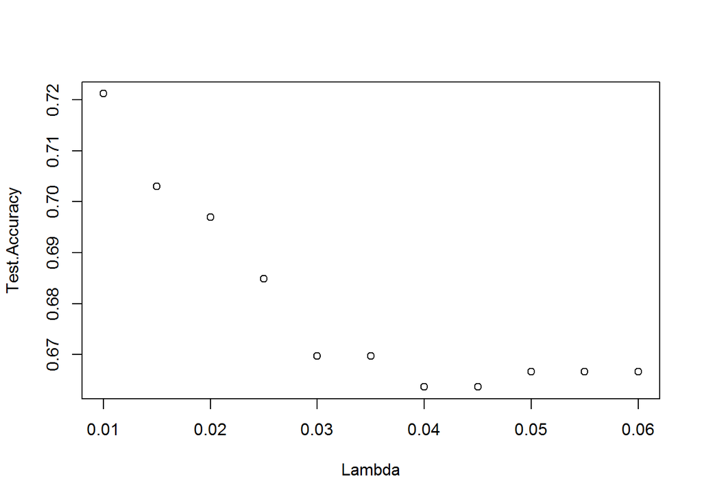

```
##
## Call:
## roc.formula(formula = ytest ~ lassoPreds[, 4])
##
## Data: lassoPreds[, 4] in 208 controls (ytest 0) < 122 cases (ytest 1).
## Area under the curve: 0.6314
```

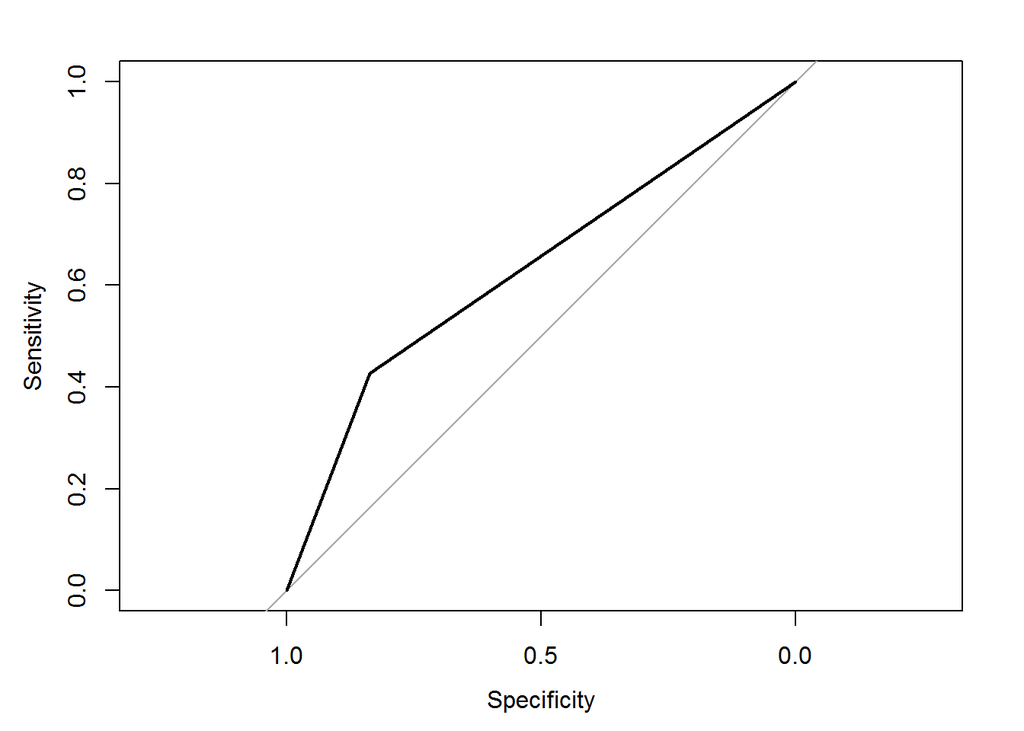

```
## 117 x 1 sparse Matrix of class "dgCMatrix"
##                                         1
## (Intercept)                 -1.034187e+00
## num_ip_post                  .
## total_los_post               .
## num_op_post                  .
## num_er_post                 -7.802021e-02
## num_ndc_post                 .
## num_gpi6_post               -8.140959e-02
## adjust_total_30d_post        5.193488e-02
## generic_rate_post            1.456848e-01
## post_ip_flag1               -4.211000e-02
## post_er_flag1                .
## post_ip_cost                 .
## post_er_cost                 .
## post_rx_cost                 .
## post_op_cost                 .
## post_total_cost              .
## post_medical_cost            .
## idx_copay                    .
## age_grpN3                    .
## age_grpN4                    .
## sexN2                        .
## regionN2                     .
## regionN3                     .
## regionN4                     .
## idx_prodtypeN2               .
## idx_prodtypeN3               .
## idx_paytypN2                 .
## idx_paytypN3                 .
## idx_paytypN4                 .
## age_cat35-44                 .
## age_cat45-54                 .
## age_cat55-64                 .
## age_cat65-74                 .
## age_cat75+                   .
## log_idx_copay                .
## ALCOHOL_DRUG1                .
## ASTHMA1                      .
## CARDIAC_ARRYTHMIA1           .
```

[output cut: 64 more lines]

```
## pre_total_cat5               .
## pre_total_cat6               8.589556e-02
## pre_total_cat7               .
## pre_total_cat8               .
## pre_total_cat9               .
## pre_total_cat10              .
## numofgen                     .
## numofbrand                   .
## generic_cost                 .
## brand_cost                   .
## ratio_G_total_cost           .
## numofgen_post                .
## numofbrand_post              .
## generic_cost_post            .
## brand_cost_post              .
```

Changes in $\lambda$ appeared to lower the test accuracy rate of the lasso regression model. For example, at $\lambda =0.03$, the AUC value decreases to 0.63.

# Results

The results for each model after cross-validation are summarized in the tables below.

[output not shown]

Although the ridge regression outperformed the lasso regression by a very small margin, to predict the total post index costs, we would opt for the lasso regression linear model with a $\lambda$ value of 0.0102 due to the decrease in complexity of the model.

[output not shown]

To classify patient drug adherence of at least 80%, we choose the lasso regression logistic model with a $\lambda$ value of 0.0122 and an AUC value of 0.78.

# Conclusion

In performing the different regression techniques, we learned that feature selection performed through statistical analysis relative to the target output is critical in reducing the complexity of the model before regression methods are applied. This helps in limiting the effects of multicolinearity in the case of the linear regression model. For the logistic model, changes to lambda within the optimal bounds in order to reduce features did not seem to improve the accuracy of our model, however, more exploration could be done to assess the selected threshold value of 0.5 that was used to classify. It is also notable that we achieved roughly the same accuracy with less variables, which reduces our risk of overfitting with future test data.

Among the potential improvements, we found that use of residual analyses can reveal that more work should be done to understand the features in the model. For this project, the objective was to make a prediction using the data with little knowledge of the background of the topic. This exercise demonstrated that within data, there is a large amount of predictive power where regression tools are used.